# GoldNewReport

Harold洪世豪

2018年11月18日

# 金价新闻与走势分析报告

### 构想

主体精神是希望对有关黄金的新闻内容分析，结合历史金价走势，总结出涨和跌的代表性关键词，并聚类验证

资料源 http://search.sina.com.cn/?c=news&q=%BB%C6%BD%F0+%BD%F0%BC%DB&range=all&time=custom&stime=2018-08-01&etime=2018-08-01&num=15&col=1_7 词典库 http://www.voidcn.com/article/p-seirhybh-xe.html

### 阶段一：

将26天的新闻根据走势图分为 涨 和 跌 两类，分别生成词频矩阵TDM，观察涨跌的热词有何异同

```r
library(NLP)
library(tm)
library(stats)
library(proxy)
library(dplyr)
```

```r
library(readtext)
library(jiebaRD)
library(jiebaR)
library(slam)
library(Matrix)
library(tidytext)
library(ggplot2)
library(wordcloud2)
library(knitr)
library(devtools)
library(scales)
library(grid)
library(factoextra)
library(ggbiplot)
#define function toSpace
toSpace <- content_transformer(
  function(x, pattern) gsub(pattern, " ", x))

#apply to tokenizer
jieba_tokenizer = function(d){
  unlist(segment(d[[1]],jiebar = mixseg))
}

#convert Finance Corpus into matrix
dict.csv <- read.csv("FinanceCorpusCH.csv",header = FALSE,encoding = "utf-8")
dict.matrix <- as.matrix(dict.csv)

#import finance term dictionary
mixseg = worker()
new_user_word(mixseg,dict.matrix)
```

```
## [1] TRUE
```

```r
new_user_word(mixseg,"以太坊")
```

```
## [1] TRUE
```

```r
new_user_word(mixseg,"避险天堂")
```

```
## [1] TRUE
```

```r
#construct the Frequency-DataFrame
RawAnalysis <- function(filepath){
  #construct raw corpus
  docs.corpus <- Corpus(DirSource(filepath),
                        readerControl = list(language = "zho"))

  # first cleaning process
  docs.corpus <- tm_map(docs.corpus,stripWhitespace)
  docs.corpus <- tm_map(docs.corpus,removeNumbers)
  docs.corpus <- tm_map(docs.corpus,toSpace,"[a-zA-Z]")



  #split the docs into terms with jiebaR worker
  seg = lapply(docs.corpus,jieba_tokenizer)

  #build the TermDocumentMatrix
  freq_fram <- as.data.frame(table(unlist(seg)))
  freq_fram <- freq_fram[-which(nchar(as.character(freq_fram$Var1))<=1),]
  freq_fram <- freq_fram[order(freq_fram$Freq,decreasing = T),]
  n = length(seg)

  return(freq_fram)
}

#get the freq_fram of decline-data
DeclinePath <- "C:\\Users\\Harold\\Documents\\GitHub\\Data-Science-and-programing\\week6_8\\text\\decline"
freq_fram_D <- RawAnalysis(DeclinePath)
kable(head(freq_fram_D,10))
```

|  | Var1 | Freq |
| --- | --- | --- |
| 3641 | 黄金 | 1462 |
| 5856 | 美元 | 1026 |
| 5824 | 美国 | 597 |
| 7647 | 市场 | 507 |
| 4441 | 金价 | 502 |
| 5844 | 美联储 | 490 |
| 4025 | 加息 | 406 |
| 11084 | 震荡 | 401 |
| 11217 | 支撑 | 375 |
| 2592 | 附近 | 363 |

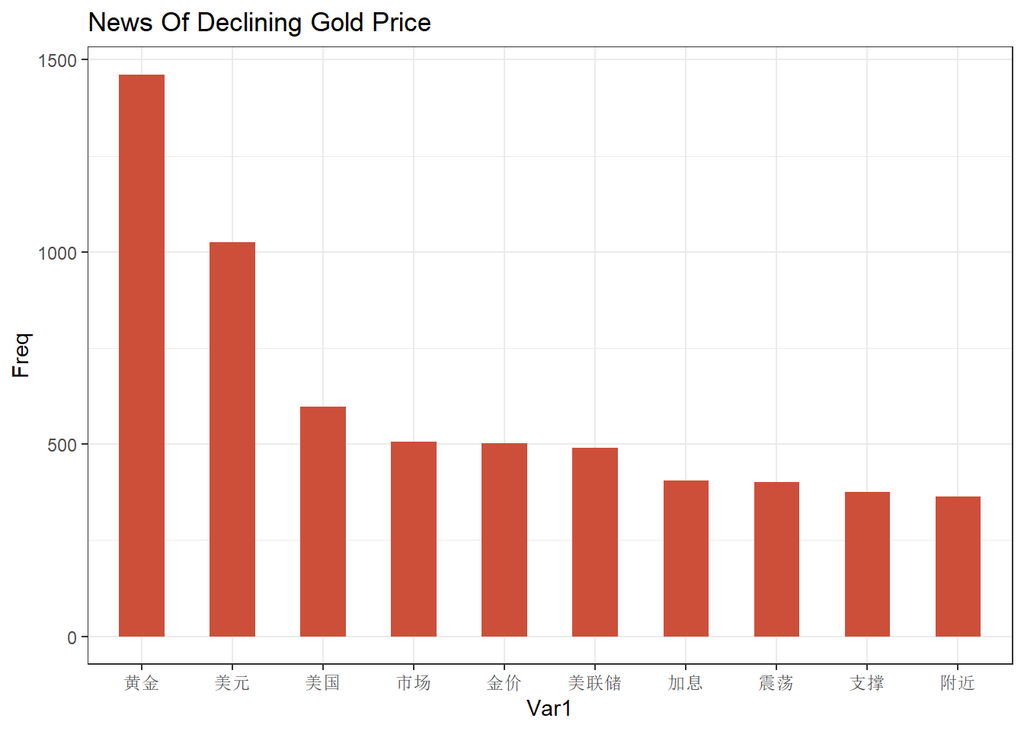

```r
#plot the histgram
plot <- freq_fram_D[1:10,1:2]
plot$Var1 <- factor(plot$Var1,levels = plot$Var1[order(-plot$Freq)])
theme_set(theme_bw())
ggplot(plot,aes(x = Var1,y = Freq))+
  geom_bar(stat = "identity",width = 0.5,fill = "tomato3")+
  labs(title = "News Of Declining Gold Price")
```

```r
#plot the wordcloud
wordcloud2(freq_fram_D)
```

[interactive chart not shown]

```r
#get the freq_fram of rise-data
RisePath <- "C:\\Users\\Harold\\Documents\\GitHub\\Data-Science-and-programing\\week6_8\\text\\rise"
freq_fram_R <- RawAnalysis(RisePath)
kable(head(freq_fram_R,10))
```

|  | Var1 | Freq |
| --- | --- | --- |
| 5818 | 黄金 | 1821 |
| 9274 | 美元 | 1527 |
| 9228 | 美国 | 1119 |
| 12214 | 市场 | 816 |
| 7079 | 金价 | 665 |
| 7274 | 经济 | 513 |
| 7873 | 可能 | 513 |
| 18077 | 中国 | 512 |
| 9136 | 贸易 | 478 |
| 14181 | 我们 | 477 |

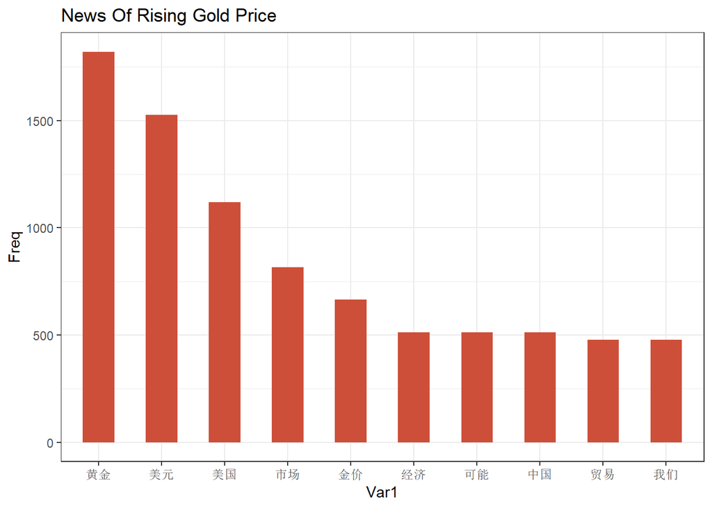

```r
#plot the histgram
plot <- freq_fram_R[1:10,1:2]
plot$Var1 <- factor(plot$Var1,levels = plot$Var1[order(-plot$Freq)])
theme_set(theme_bw())
ggplot(plot,aes(x = Var1,y = Freq))+
  geom_bar(stat = "identity",width = 0.5,fill = "tomato3")+
  labs(title = "News Of Rising Gold Price")
```

```r
#plot the wordcloud
wordcloud2(freq_fram_R)
```

[interactive chart not shown]

### 阶段性结论1：

当一天的新闻反复提及，强调，分析美联储，加息，市场震荡等议题时，可能在预示第二天金价会跌；另一方面，若更多的在讨论经济，贸易，或多次使用中国，我们这种第一人称时，可能在预示第二天金价要涨！（赔钱别找我！）

### 阶段二：

先把涨和跌的新闻混杂在一起，生成TF-IDF，排序后获取每个日期文件的代表性前5的词语

```r
#construct raw corpus
filepath <- "C:\\Users\\Harold\\Documents\\GitHub\\Data-Science-and-programing\\week6_8\\text\\whole"
docs.corpus <- Corpus(DirSource(filepath),
                      readerControl = list(language = "zho"))

# first cleaning process
docs.corpus <- tm_map(docs.corpus,stripWhitespace)
docs.corpus <- tm_map(docs.corpus,removeNumbers)
docs.corpus <- tm_map(docs.corpus,toSpace,"[a-zA-Z]")
docs.corpus <- tm_map(docs.corpus,toSpace,"上周五")
docs.corpus <- tm_map(docs.corpus,toSpace,"上周四")
docs.corpus <- tm_map(docs.corpus,toSpace,"上周三")
docs.corpus <- tm_map(docs.corpus,toSpace,"上周二")
docs.corpus <- tm_map(docs.corpus,toSpace,"上周一")
docs.corpus <- tm_map(docs.corpus,toSpace,"上周六")
docs.corpus <- tm_map(docs.corpus,toSpace,"上周日")
docs.corpus <- tm_map(docs.corpus,toSpace,"一月")
docs.corpus <- tm_map(docs.corpus,toSpace,"二月")
docs.corpus <- tm_map(docs.corpus,toSpace,"三月")
docs.corpus <- tm_map(docs.corpus,toSpace,"四月")
docs.corpus <- tm_map(docs.corpus,toSpace,"五月")
docs.corpus <- tm_map(docs.corpus,toSpace,"六月")
docs.corpus <- tm_map(docs.corpus,toSpace,"七月")
docs.corpus <- tm_map(docs.corpus,toSpace,"八月")
docs.corpus <- tm_map(docs.corpus,toSpace,"九月")
docs.corpus <- tm_map(docs.corpus,toSpace,"十月")
docs.corpus <- tm_map(docs.corpus,toSpace,"十一月")
docs.corpus <- tm_map(docs.corpus,toSpace,"十二月")
docs.corpus <- tm_map(docs.corpus,toSpace,"该行")
docs.corpus <- tm_map(docs.corpus,toSpace,"星期一")
docs.corpus <- tm_map(docs.corpus,toSpace,"星期二")
docs.corpus <- tm_map(docs.corpus,toSpace,"星期三")
docs.corpus <- tm_map(docs.corpus,toSpace,"星期四")
docs.corpus <- tm_map(docs.corpus,toSpace,"星期五")
docs.corpus <- tm_map(docs.corpus,toSpace,"星期六")
docs.corpus <- tm_map(docs.corpus,toSpace,"星期天")
docs.corpus <- tm_map(docs.corpus,toSpace,"今晚")


#split the docs into terms with jiebaR worker
seg = lapply(docs.corpus,jieba_tokenizer)

#build the TermDocumentMatrix
count_token = function(d)
{
  as.data.frame(table(d))
}
freq_fram <- lapply(seg,count_token)
for(id in 1:length(freq_fram))
{
  freq_fram[[id]] <- freq_fram[[id]][-which(nchar(as.character(freq_fram[[id]]$d))<=1),]
}
#freq_fram <- freq_fram[order(freq_fram$Freq,decreasing = T),]
n = length(seg)
TDM <- freq_fram[[1]]
colNames <- names(seg)
colNames <- gsub(".txt","",colNames)
kable(head(TDM))
```

|  | d | Freq |
| --- | --- | --- |
| 1 | 阿根廷 | 2 |
| 3 | 埃文斯 | 1 |
| 5 | 安邦 | 1 |
| 6 | 安全 | 3 |
| 7 | 安危 | 1 |
| 8 | 安在 | 1 |

```r
for(id in c(2:n))
{
  TDM = merge(TDM,freq_fram[[id]],by = "d",all = TRUE)
  names(TDM) = c('d',colNames[1:id])
}
TDM[is.na(TDM)] <- 0
names(TDM) = c('d',colNames[2:n])

kable(head(TDM))
```

| d | text0910 | text0911 | text0912 | text0913 | text0914 | text0915 | text0916 | text0917 | text0918 | text0919 | text092 | text0920 | text0921 | text0922 | text0923 | text0925 | text0926 | text0928 | text093 | text094 | text095 | text096 | text097 | text098 | text099 | NA |
| --- | --- | --- | --- | --- | --- | --- | --- | --- | --- | --- | --- | --- | --- | --- | --- | --- | --- | --- | --- | --- | --- | --- | --- | --- | --- | --- |
| 阿根廷 | 2 | 0 | 0 | 0 | 0 | 0 | 1 | 5 | 0 | 0 | 0 | 8 | 0 | 1 | 0 | 0 | 1 | 0 | 1 | 1 | 23 | 1 | 0 | 0 | 1 | 5 |
| 埃文斯 | 1 | 0 | 0 | 0 | 0 | 0 | 3 | 0 | 1 | 0 | 0 | 0 | 0 | 0 | 0 | 0 | 0 | 0 | 0 | 2 | 1 | 0 | 0 | 2 | 0 | 1 |
| 安邦 | 1 | 0 | 0 | 0 | 0 | 0 | 0 | 0 | 0 | 0 | 0 | 0 | 0 | 0 | 0 | 0 | 0 | 0 | 0 | 0 | 0 | 0 | 0 | 0 | 1 | 0 |
| 安全 | 3 | 0 | 2 | 0 | 1 | 0 | 5 | 4 | 1 | 0 | 1 | 38 | 0 | 0 | 0 | 1 | 0 | 0 | 0 | 0 | 0 | 1 | 2 | 1 | 3 | 4 |
| 安危 | 1 | 0 | 0 | 0 | 0 | 0 | 0 | 0 | 0 | 0 | 0 | 0 | 0 | 0 | 0 | 0 | 0 | 0 | 0 | 0 | 0 | 0 | 0 | 0 | 0 | 0 |
| 安在 | 1 | 0 | 0 | 0 | 0 | 0 | 0 | 0 | 0 | 0 | 0 | 0 | 0 | 0 | 0 | 0 | 0 | 0 | 0 | 0 | 0 | 0 | 0 | 0 | 0 | 0 |

```r
#function to calculate idf
idfCal <- function(word_doc)
{
  log2(n / nnzero(word_doc))
}
idf <- apply(as.matrix(TDM[,2:(n+1)]),1,idfCal)
tf <- apply(as.matrix(TDM[,2:(n+1)]),2,sum)


doc.tfidf <- TDM

tempY <- matrix(rep(c(as.matrix(tf)), each = length(idf)), nrow = length(idf))
tempX <- matrix(rep(c(as.matrix(idf)), each = length(tf)), ncol = length(tf), byrow = TRUE)
doc.tfidf[,2:(n+1)] <- (doc.tfidf[,2:(n+1)] / tempY) * tempX
stopLine <- rowSums(doc.tfidf[,2:(n+1)])
delID <- which(stopLine == 0)

TDM <- TDM[-delID,]
doc.tfidf <- doc.tfidf[-delID,]
TopWords = data.frame()
for( id in c(1:n) ){
  dayMax = order(doc.tfidf[,id+1], decreasing = TRUE)
  showResult = t(as.data.frame(doc.tfidf[dayMax[1:5],1]))
  TopWords = rbind(TopWords, showResult)
}
rownames(TopWords) = colNames[1:n]
TopWords = droplevels(TopWords)
kable(TopWords)
```

|  | V1 | V2 | V3 | V4 | V5 |
| --- | --- | --- | --- | --- | --- |
| text091 | 农发行 | 徐水 | 万达 | 融创 | 双隆 |
| text0910 | 非农 | 薪资 | 布林线 | 携手 | 好于预期 |
| text0911 | 港股通 | 恒生 | 险些 | 矿区 | 空仓 |
| text0912 | 林带 | 止损 | 布林线 | 中轨 | 双线 |
| text0913 | 房地产 | 敞口 | 迁徙 | 房贷 | 城市 |
| text0914 | 销售数据 | 德拉 | 率料 | 奥巴马 | 邀请 |
| text0915 | 加多 | 威尔逊 | 无印良品 | 克林顿 | 美年 |
| text0916 | 催收 | 台风 | 安踏 | 清算 | 毒药 |
| text0917 | 会晤 | 平壤 | 瑞郎 | 比重 | 储备 |
| text0918 | 聚酯 | 供需 | 检修 | 装置 | 首脑会晤 |
| text0919 | 避险天堂 | 默认 | 换期 | 压低 | 原产 |
| text092 | 乙醇 | 顺风 | 中报 | 季报 | 滴滴 |
| text0920 | 宣言 | 金正恩 | 台阶 | 万户 | 比率 |
| text0921 | 蒙特利尔银行 | 铂金 | 打到 | 二浪 | 林带 |
| text0922 | 奇瑞 | 茅台 | 尹同 | 万户 | 控股 |
| text0923 | 地铁 | 唐宏波 | 西安 | 飞利浦 | 西安市 |
| text0925 | 比率 | 德拉 | 巴理克 | 比价 | 名义收益 |
| text0926 | 订阅 | 鲍威尔 | 长江 | 长江证券 | 评级 |
| text0928 | 副行长 | 出任 | 离职 | 银行高管 | 去向 |
| text093 | 非农 | 空仓 | 投机 | 买价 | 卖价 |
| text094 | 牛肉 | 非农 | 阿根廷 | 休市 | 劳动节 |
| text095 | 房地产 | 麦戈隆 | 敞口 | 迁徙 | 房贷 |
| text096 | 蔡某 | 非农 | 微信群 | 被害人 | 团伙 |
| text097 | 非农 | 强劲增长 | 凤金 | 斯特 | 劳动力 |
| text098 | 以太坊 | 重汽 | 谭旭光 | 潍柴 | 银业 |
| text099 | 回购 | 潮流 | 可口可乐 | 天台 | 城市 |

```r
TopWords_R <- TopWords[a<-c(3,4,6,7,8,10,14,15,16,21,22,24,25,26),]
#Rise
kable(TopWords_R)
```

|  | V1 | V2 | V3 | V4 | V5 |
| --- | --- | --- | --- | --- | --- |
| text0911 | 港股通 | 恒生 | 险些 | 矿区 | 空仓 |
| text0912 | 林带 | 止损 | 布林线 | 中轨 | 双线 |
| text0914 | 销售数据 | 德拉 | 率料 | 奥巴马 | 邀请 |
| text0915 | 加多 | 威尔逊 | 无印良品 | 克林顿 | 美年 |
| text0916 | 催收 | 台风 | 安踏 | 清算 | 毒药 |
| text0918 | 聚酯 | 供需 | 检修 | 装置 | 首脑会晤 |
| text0921 | 蒙特利尔银行 | 铂金 | 打到 | 二浪 | 林带 |
| text0922 | 奇瑞 | 茅台 | 尹同 | 万户 | 控股 |
| text0923 | 地铁 | 唐宏波 | 西安 | 飞利浦 | 西安市 |
| text094 | 牛肉 | 非农 | 阿根廷 | 休市 | 劳动节 |
| text095 | 房地产 | 麦戈隆 | 敞口 | 迁徙 | 房贷 |
| text097 | 非农 | 强劲增长 | 凤金 | 斯特 | 劳动力 |
| text098 | 以太坊 | 重汽 | 谭旭光 | 潍柴 | 银业 |
| text099 | 回购 | 潮流 | 可口可乐 | 天台 | 城市 |

```r
#Decline
TopWords_D <- TopWords[-a,]
kable(TopWords_D)
```

[output not shown]

避险天堂(http://finance.sina.com.cn/money/forex/forexanaly/2018-09-19/doc-ihkhfqns7600259.shtml)

非农(https://24k99.fx168.com/opinion/1809/2652956.shtml)

会晤(http://finance.sina.com.cn/money/nmetal/hjzx/2018-09-17/doc-ifxeuwwr5123815.shtml)

蒙特利尔银行(http://finance.sina.com.cn/money/nmetal/hjzx/2018-09-21/doc-ihkhfqnt3537271.shtml)

以太坊(https://tech.sina.com.cn/i/2018-09-09/doc-ihivtsyk3248387.shtml)

地铁(http://finance.sina.com.cn/china/gncj/2018-09-23/doc-ifxeuwwr7443274.shtml)

```r
 library(ggfortify)
```

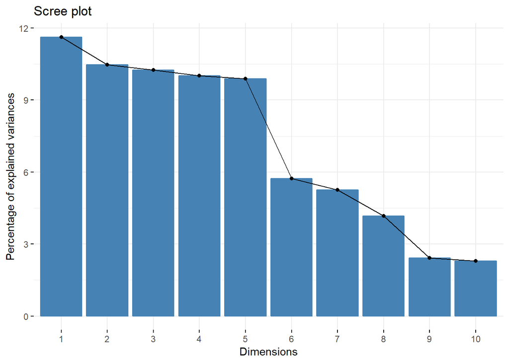

```r
 word.doc.tfidf <- subset(doc.tfidf,select = -d)
 row.names(word.doc.tfidf) <- doc.tfidf$d
 pcs.date <- prcomp(t(word.doc.tfidf), center = T, scale = T)

 fviz_eig(pcs.date)
```

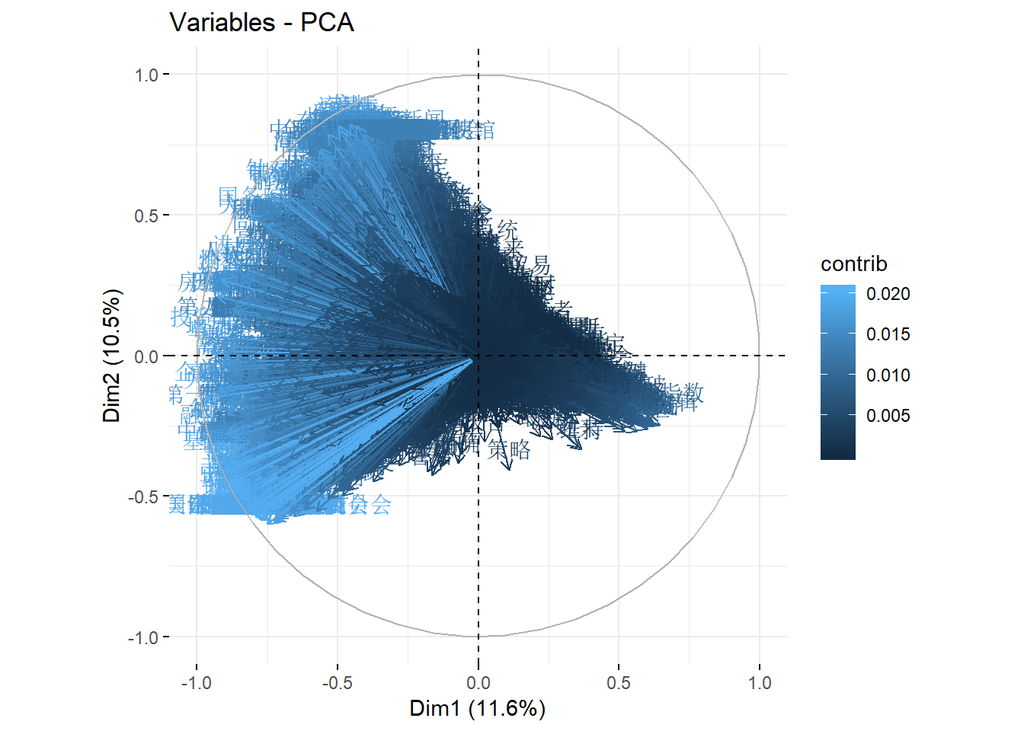

```r
 fviz_pca_var(pcs.date, col.var = "contrib")
```

```r
 str(pcs.date)
```

```
## List of 5
##  $ sdev    : num [1:26] 50.3 47.7 47.2 46.6 46.4 ...
##  $ rotation: num [1:21740, 1:26] 0.000483 0.001109 0.000684 -0.007888 0.000695 ...
##   ..- attr(*, "dimnames")=List of 2
##   .. ..$ : chr [1:21740] "阿根廷" "埃文斯" "安邦" "安全" ...
##   .. ..$ : chr [1:26] "PC1" "PC2" "PC3" "PC4" ...
##  $ center  : Named num [1:21740] 2.46e-04 8.55e-05 2.95e-05 1.56e-04 1.66e-05 ...
##   ..- attr(*, "names")= chr [1:21740] "阿根廷" "埃文斯" "安邦" "安全" ...
##  $ scale   : Named num [1:21740] 6.76e-04 1.70e-04 1.05e-04 2.74e-04 8.48e-05 ...
##   ..- attr(*, "names")= chr [1:21740] "阿根廷" "埃文斯" "安邦" "安全" ...
##  $ x       : num [1:26, 1:26] 8.61 24.29 24.17 25.86 20.67 ...
##   ..- attr(*, "dimnames")=List of 2
##   .. ..$ : chr [1:26] "text0910" "text0911" "text0912" "text0913" ...
##   .. ..$ : chr [1:26] "PC1" "PC2" "PC3" "PC4" ...
##  - attr(*, "class")= chr "prcomp"
```

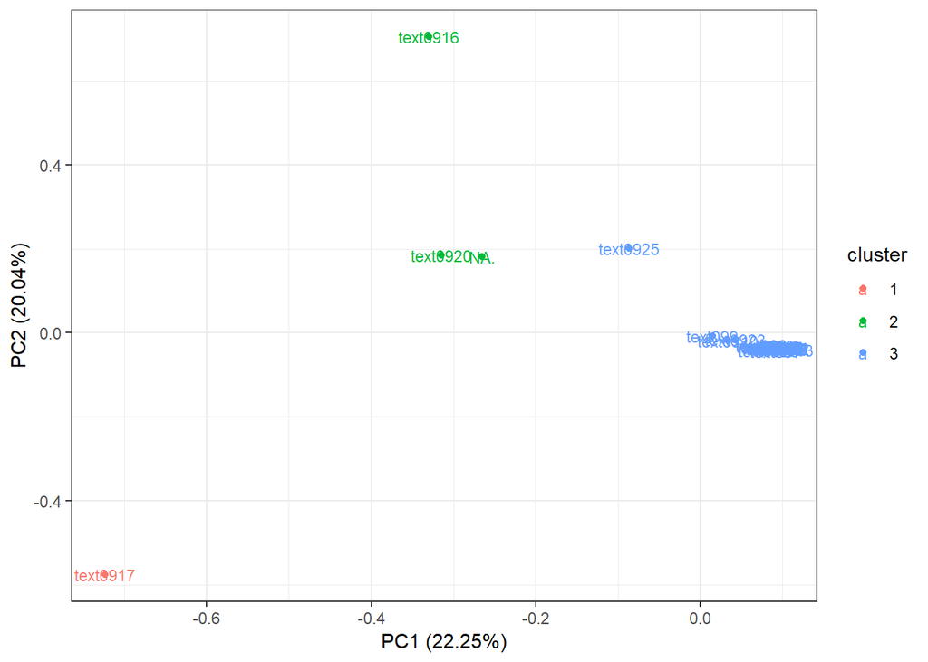

```r
 k.date <- 3
 princomp.date <- data.frame(pcs.date$x[,1:5])
 View(princomp.date)
 km.date <- kmeans(princomp.date,centers = k.date,nstart=26, iter.max=1000)
 autoplot(km.date, data = pcs.date, label = TRUE, label.size = 3)
```

`有人会问，最后得出这么个结论是不是在做白工呢？我认为这非常好验证了投资有风险，买金需谨慎，黄金投资的新闻少看，基本都在扯咸蛋。以前别人质疑投资评论员但是没有依据，但是现在可以看到，他们的新闻与第二天的涨跌关系基本属于随机分布。